# AFA - 1st Session

Mathis Mourey

# R for AFA - 1st session - Introduction to R

## Introduction to R programming

We assign values to varaibles by using either the equal sign or the an left arrow sign. The function print() and cat() allow for putting sentences into your code. They are particularly useful for announcing errors in a function/loop.

```r
x_1 = 2
x_2 <- 2
y_1 = x_1 + x_2**2

cat('x_1 is equal to', x_1, 'while x_2 is', x_2, '. Wait. It is the same!')
```

```
## x_1 is equal to 2 while x_2 is 2 . Wait. It is the same!
```

In order to perform more complex operations we use predefined functions. Such as the following:

```r
sqrt(y_1)
```

```
## [1] 2.44949
```

```r
log(x_1)
```

```
## [1] 0.6931472
```

```r
exp(y_1)
```

```
## [1] 403.4288
```

A useful fonctionality is the #, that allows you to comment your code in order to make it usable and readable by others. Also, when the predefined functions in the basic R aren’t enough, we can call packages, using the library() function. Packages are a set of user-defined functions that are the main reasons why R is such a great open-source langage. In the example below, we use the package *Quantmod* in order to access yahoo finance database and download prices and volume directly into RStudio.

```r
options(warn=-1)
library(quantmod)
# downloading all the available market data on Facebook
df = getSymbols('FB', env=NULL)
```

[output not shown]

```r
# shows the first lines of a table
head(df)
```

```
##            FB.Open FB.High FB.Low FB.Close FB.Volume FB.Adjusted
## 2012-05-18   42.05   45.00  38.00    38.23 573576400       38.23
## 2012-05-21   36.53   36.66  33.00    34.03 168192700       34.03
## 2012-05-22   32.61   33.59  30.94    31.00 101786600       31.00
## 2012-05-23   31.37   32.50  31.36    32.00  73600000       32.00
## 2012-05-24   32.95   33.21  31.77    33.03  50237200       33.03
## 2012-05-25   32.90   32.95  31.11    31.91  37149800       31.91
```

Most of the time we use matrix calculus in order to perform quickly complex operations. Especially, matrix calculus will be usefull for determining efficient portfolio in the Markowitz framework later on. We can create a vector in the following way

```r
matrix(nrow=1, ncol=4)
```

```
##      [,1] [,2] [,3] [,4]
## [1,]   NA   NA   NA   NA
```

```r
c(1,2,33,21)
```

```
## [1]  1  2 33 21
```

```r
rep(1,10)
```

```
##  [1] 1 1 1 1 1 1 1 1 1 1
```

```r
seq(0,10,1)
```

```
##  [1]  0  1  2  3  4  5  6  7  8  9 10
```

The code above shows different approaches: You can create vector either by creating a matrix of 1 row or 1 column using the matrix() function; or by using the function c() that binds values together; the function rep() that create a vector of a repetition of a value; the function seq() that create a vector of an interval between two values, with a given step.

### Useful functions

```r
# first 2 numbers
head(rep(1, 10), 2)
```

```
## [1] 1 1
```

```r
#last 4 numbers
tail(seq(0,10, 1), 4)
```

```
## [1]  7  8  9 10
```

```r
#length of the vector
length(c(1,2,33,21))
```

```
## [1] 4
```

```r
#Dimension of a matrix: only with matrices
dim(matrix(nrow=1, ncol=4))
```

```
## [1] 1 4
```

```r
# cbind associate two or more vectors in columns
mat_1 = cbind(c(1,2,1,2), c(3,4,2,1))
mat_1
```

```
##      [,1] [,2]
## [1,]    1    3
## [2,]    2    4
## [3,]    1    2
## [4,]    2    1
```

```r
#rbind associate two or more vectors in rows
mat_2 = rbind(c(1,2,1,2), c(3,4,2,1))
mat_2
```

```
##      [,1] [,2] [,3] [,4]
## [1,]    1    2    1    2
## [2,]    3    4    2    1
```

```r
# square matrix
mat_3 = rbind(c(1,2), c(2,3))
mat_3
```

```
##      [,1] [,2]
## [1,]    1    2
## [2,]    2    3
```

When performing operations between matrices be sure of keeping in mind the size and dimensions of your data.

```r
#Multplication
mat_2 %*% mat_1
```

```
##      [,1] [,2]
## [1,]   10   15
## [2,]   15   30
```

```r
#Inverse of a matrix
solve(mat_3)
```

```
##      [,1] [,2]
## [1,]   -3    2
## [2,]    2   -1
```

```r
#Tranpose of a matrix
t(mat_1)
```

```
##      [,1] [,2] [,3] [,4]
## [1,]    1    2    1    2
## [2,]    3    4    2    1
```

```r
#Addition of matrices
mat_2 + t(mat_1)
```

```
##      [,1] [,2] [,3] [,4]
## [1,]    2    4    2    4
## [2,]    6    8    4    2
```

One other type of variable that will be important is the *list*. Lists could be thought of, s a vector but it can consist of strings, numbers, matrices, … it is especially useful when you are looking at the evolution of a covariance matrix for instance.

```r
#Create a list without anything inside a add afterwards
l = list()
l[[1]] = 12
l[[2]] = c(1,2,1)
l[[3]] = 'hello'
l
```

```
## [[1]]
## [1] 12
##
## [[2]]
## [1] 1 2 1
##
## [[3]]
## [1] "hello"
```

```r
l_1 = list(12, c(1,2,1), 'hello')
l_1
```

```
## [[1]]
## [1] 12
##
## [[2]]
## [1] 1 2 1
##
## [[3]]
## [1] "hello"
```

Finally, loops will be the most important feature to know. Sometimes, you will need to adjust particular measurement or to create your own functions. Knowing how to use loops will be a great advantage in term of efficiency and clarity of the code.

```r
#for
for(i in 1:10){
    print(i)
}
```

```
## [1] 1
## [1] 2
## [1] 3
## [1] 4
## [1] 5
## [1] 6
## [1] 7
## [1] 8
## [1] 9
## [1] 10
```

```r
#if
if(x_1 == 1){
    print('Noice')
} else if(x_1 != 2){
    print('Smort')
} else {
    print('too bad')
}
```

```
## [1] "too bad"
```

```r
# Combine list and loop to create tensors
my_tensor = list()
for(i in 1:3){
    my_tensor[[i]] = matrix(1, nrow=2, ncol=2)
}

my_tensor
```

```
## [[1]]
##      [,1] [,2]
## [1,]    1    1
## [2,]    1    1
##
## [[2]]
##      [,1] [,2]
## [1,]    1    1
## [2,]    1    1
##
## [[3]]
##      [,1] [,2]
## [1,]    1    1
## [2,]    1    1
```

```r
# or function lapply works fine as well
my_tensor_2 = lapply(1:3, function(x) matrix(1, nrow=2, ncol=2))
my_tensor_2
```

```
## [[1]]
##      [,1] [,2]
## [1,]    1    1
## [2,]    1    1
##
## [[2]]
##      [,1] [,2]
## [1,]    1    1
## [2,]    1    1
##
## [[3]]
##      [,1] [,2]
## [1,]    1    1
## [2,]    1    1
```

## Handling your data in R

```r
library(openxlsx)
df = read.xlsx('dataset_AFA.xlsx', sheet = 'Market_Data')
summary(df)
```

```
##      Dates           AAPL.R           AAPL.V              TSLA.R
##  Min.   :43368   Min.   : 35.55   Min.   : 45448000   Min.   : 35.79
##  1st Qu.:43551   1st Qu.: 49.17   1st Qu.: 94302500   1st Qu.: 51.62
##  Median :43732   Median : 56.08   Median :121304600   Median : 66.98
##  Mean   :43731   Mean   : 63.86   Mean   :133685508   Mean   :110.75
##  3rd Qu.:43913   3rd Qu.: 75.71   3rd Qu.:162250800   3rd Qu.:146.08
##  Max.   :44092   Max.   :134.18   Max.   :382978400   Max.   :498.32
##      TSLA.V               GM.R            GM.V               FB.R
##  Min.   : 10852700   Min.   :16.80   Min.   : 2924200   Min.   :124.1
##  1st Qu.: 33348500   1st Qu.:30.15   1st Qu.: 7741150   1st Qu.:166.2
##  Median : 46626500   Median :35.52   Median :10531950   Median :187.5
##  Mean   : 57993796   Mean   :33.53   Mean   :11965031   Mean   :190.6
##  3rd Qu.: 74878750   3rd Qu.:37.77   3rd Qu.:14825925   3rd Qu.:208.2
##  Max.   :304694000   Max.   :40.88   Max.   :52000000   Max.   :303.9
##       FB.V              DJI.R           DJI.V
##  Min.   : 6046300   Min.   :18592   Min.   :8.615e+07
##  1st Qu.:12946300   1st Qu.:25323   1st Qu.:2.561e+08
##  Median :17656800   Median :26186   Median :3.097e+08
##  Mean   :20461070   Mean   :26097   Mean   :3.485e+08
##  3rd Qu.:24454950   3rd Qu.:27159   3rd Qu.:3.907e+08
##  Max.   :77233600   Max.   :29551   Max.   :2.191e+09
```

There is two types of data in the same dataframe. First, there is **.R** (price data) and **.V** (volume data). We start off by making two distinct dataframes for each types. Also, R has the bad habit to change date object into numeric variables. Here, the date column in actually the number of days since 1st January 1900. We use the function **as.Date** to create back the dates.

```r
price = volume = data.frame(matrix(nrow=nrow(df), ncol = (ncol(df)-1)/2 + 1))

#initialy put dates as the first columns for both df

price[,1] = volume[,1] = as.Date(df$Dates, origin='1899-12-30')

r=2
for(i in seq(2, ncol(df), 2)){
  price[,r] = df[,i]
  volume[,r] = df[,(i+1)]
  r = r +1
}

colnames(price) = colnames(volume) = c('Dates', 'AAPL', 'TSLA', 'GM', 'FB', 'DJI')
head(price)
```

```
##        Dates    AAPL   TSLA    GM     FB      DJI
## 1 2018-09-25 55.5475 60.198 33.55 164.91 26492.21
## 2 2018-09-26 55.1050 61.916 33.73 166.95 26385.28
## 3 2018-09-27 56.2375 61.504 33.67 168.84 26439.93
## 4 2018-09-28 56.4350 52.954 33.67 164.46 26458.31
## 5 2018-10-01 56.8150 62.140 34.20 162.44 26651.21
## 6 2018-10-02 57.3200 60.204 33.30 159.33 26773.94
```

```r
head(volume)
```

```
##        Dates      AAPL      TSLA       GM       FB       DJI
## 1 2018-09-25  98217600  22408500 14805300 27622800 234110000
## 2 2018-09-26  95938800  39216000 18074500 25252200 262620000
## 3 2018-09-27 120724800  42545500 11659300 27266900 226350000
## 4 2018-09-28  91717600 168248500  8836700 34265600 264030000
## 5 2018-10-01  94403200 108888000 13737600 26407700 238320000
## 6 2018-10-02  99152800  58717500 22731200 36031000 258290000
```

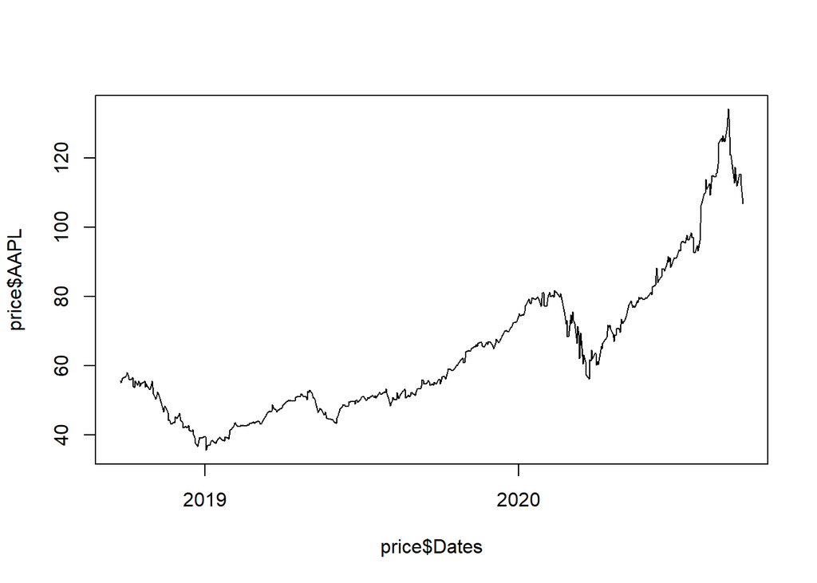

```r
plot(price$Dates, price$AAPL, type='l')
```

Once you’ve done everything you needed with your data, you can write excel files with a dataframe in each worksheet.

```r
library(xlsx)
write.xlsx(price, file="my_own_dataset.xlsx", sheetName="price", row.names=FALSE)
write.xlsx(volume, file="my_own_dataset.xlsx", sheetName="volume", append=TRUE, row.names=FALSE) #append=T if the file is already existing
```